# Приоритизация маркетинговых гипотез. Анализ результатов А/В-теста на отличия в среднем чеке и конверсии пользователей.

**Отделом маркетинга интернет-магазина подготовлен список гипотез для увеличения выручки.**

**Задачи исследования**:

- выбрать подход к приоритизации гипотез
- провести анализ влияния внедрения выбранной гипотезы на ключевые метрики компании при помощи A/B-теста

**Анализ строится в несколько этапов:**

- работа с приоритетами гипотез с использованием фреймфорков ICE, RICE;
- анализ результатов А/В-теста, проверка данных на достаточность выборки, качество распределения пользователей по исследуемым группам, наличие аномальных значений, проверка на пропуски и дубликаты, анализ типа переменных;
- анализ ключевых метрик (средний чек, конверсия в заказы) в динамике в разрезе групп, отдельно для "сырых" и "очищенных" данных;
- проверка статистических гипотез и расчет статистики при помощи теста Манна-Уитни;
- интерпретация результатов;
- выводы по сравниваемым группам и рекомендации относительно дальнейших шагов по итогам проведенного теста.

```python
#импортируем нужные библиотеки
import pandas as pd
import datetime as dt
import numpy as np
import matplotlib.pyplot as plt
import scipy.stats as stats
from pandas.plotting import register_matplotlib_converters
```

## Часть 1. Приоритизация маркетинговых гипотез.

```python
data = pd.read_csv('C:/Users/okald/datasets/hypothesis.csv', sep=',')
data.columns = data.columns.str.lower()
data
```

|  | hypothesis | reach | impact | confidence | efforts |
| --- | --- | --- | --- | --- | --- |
| 0 | Добавить два новых канала привлечения трафика,... | 3 | 10 | 8 | 6 |
| 1 | Запустить собственную службу доставки, что сок... | 2 | 5 | 4 | 10 |
| 2 | Добавить блоки рекомендаций товаров на сайт ин... | 8 | 3 | 7 | 3 |
| 3 | Изменить структура категорий, что увеличит кон... | 8 | 3 | 3 | 8 |
| 4 | Изменить цвет фона главной страницы, чтобы уве... | 3 | 1 | 1 | 1 |
| 5 | Добавить страницу отзывов клиентов о магазине,... | 3 | 2 | 2 | 3 |
| 6 | Показать на главной странице баннеры с актуаль... | 5 | 3 | 8 | 3 |
| 7 | Добавить форму подписки на все основные страни... | 10 | 7 | 8 | 5 |
| 8 | Запустить акцию, дающую скидку на товар в день... | 1 | 9 | 9 | 5 |

**Пояснения к значению переменных:**

- hypothesis — краткое описание гипотезы;
- reach — охват пользователей по 10-балльной шкале;
- impact — влияние на пользователей по 10-балльной шкале;
- confidence — уверенность в гипотезе по 10-балльной шкале;
- efforts — затраты ресурсов на проверку гипотезы по 10-балльной шкале. Чем больше значение Efforts, тем дороже проверка гипотезы.

### Фреймворк ICE для приоритизации маркетинговых гипотез.

$$ICE = \frac{Impact * Confidence}{Efforts}$$

```python
pd.set_option("max_colwidth", 110)
```

```python
data['ICE'] = round((data['impact']*data['confidence'])/data['efforts'], 1)
data[['hypothesis', 'ICE']].sort_values('ICE', ascending = False)
```

|  | hypothesis | ICE |
| --- | --- | --- |
| 8 | Запустить акцию, дающую скидку на товар в день рождения | 16.2 |
| 0 | Добавить два новых канала привлечения трафика, что позволит привлекать на 30% больше пользователей | 13.3 |
| 7 | Добавить форму подписки на все основные страницы, чтобы собрать базу клиентов для email-рассылок | 11.2 |
| 6 | Показать на главной странице баннеры с актуальными акциями и распродажами, чтобы увеличить конверсию | 8.0 |
| 2 | Добавить блоки рекомендаций товаров на сайт интернет магазина, чтобы повысить конверсию и средний чек заказа | 7.0 |
| 1 | Запустить собственную службу доставки, что сократит срок доставки заказов | 2.0 |
| 5 | Добавить страницу отзывов клиентов о магазине, что позволит увеличить количество заказов | 1.3 |
| 3 | Изменить структура категорий, что увеличит конверсию, т.к. пользователи быстрее найдут нужный товар | 1.1 |
| 4 | Изменить цвет фона главной страницы, чтобы увеличить вовлеченность пользователей | 1.0 |

**Гипотезы с индексами 8, 0, 7, 6 и 2 - самые перспективные. Остальные 4 варианта гипотез cильно уступают по ICE-score.**

### Фреймворк RICE для приоритизации маркетинговых гипотез.

$$RICE = \frac{Rearch * Impact * Confidence}{Efforts}$$

```python
data['RICE'] = (data['reach']*data['impact']*data['confidence'])/data['efforts']
data[['hypothesis', 'RICE']].sort_values('RICE', ascending = False)
```

|  | hypothesis | RICE |
| --- | --- | --- |
| 7 | Добавить форму подписки на все основные страницы, чтобы собрать базу клиентов для email-рассылок | 112.0 |
| 2 | Добавить блоки рекомендаций товаров на сайт интернет магазина, чтобы повысить конверсию и средний чек заказа | 56.0 |
| 0 | Добавить два новых канала привлечения трафика, что позволит привлекать на 30% больше пользователей | 40.0 |
| 6 | Показать на главной странице баннеры с актуальными акциями и распродажами, чтобы увеличить конверсию | 40.0 |
| 8 | Запустить акцию, дающую скидку на товар в день рождения | 16.2 |
| 3 | Изменить структура категорий, что увеличит конверсию, т.к. пользователи быстрее найдут нужный товар | 9.0 |
| 1 | Запустить собственную службу доставки, что сократит срок доставки заказов | 4.0 |
| 5 | Добавить страницу отзывов клиентов о магазине, что позволит увеличить количество заказов | 4.0 |
| 4 | Изменить цвет фона главной страницы, чтобы увеличить вовлеченность пользователей | 3.0 |

```python
#Объединенная таблица с сортировкой по RICE и ICE
data = data.sort_values(['RICE', 'ICE'], ascending = [False, False])
data
```

|  | hypothesis | reach | impact | confidence | efforts | ICE | RICE |
| --- | --- | --- | --- | --- | --- | --- | --- |
| 7 | Добавить форму подписки на все основные страницы, чтобы собрать базу клиентов для email-рассылок | 10 | 7 | 8 | 5 | 11.2 | 112.0 |
| 2 | Добавить блоки рекомендаций товаров на сайт интернет магазина, чтобы повысить конверсию и средний чек заказа | 8 | 3 | 7 | 3 | 7.0 | 56.0 |
| 0 | Добавить два новых канала привлечения трафика, что позволит привлекать на 30% больше пользователей | 3 | 10 | 8 | 6 | 13.3 | 40.0 |
| 6 | Показать на главной странице баннеры с актуальными акциями и распродажами, чтобы увеличить конверсию | 5 | 3 | 8 | 3 | 8.0 | 40.0 |
| 8 | Запустить акцию, дающую скидку на товар в день рождения | 1 | 9 | 9 | 5 | 16.2 | 16.2 |
| 3 | Изменить структура категорий, что увеличит конверсию, т.к. пользователи быстрее найдут нужный товар | 8 | 3 | 3 | 8 | 1.1 | 9.0 |
| 1 | Запустить собственную службу доставки, что сократит срок доставки заказов | 2 | 5 | 4 | 10 | 2.0 | 4.0 |
| 5 | Добавить страницу отзывов клиентов о магазине, что позволит увеличить количество заказов | 3 | 2 | 2 | 3 | 1.3 | 4.0 |
| 4 | Изменить цвет фона главной страницы, чтобы увеличить вовлеченность пользователей | 3 | 1 | 1 | 1 | 1.0 | 3.0 |

**Гипотезы с индексами 7, 2, 0, 6 и 8 (тот же набор, что и для ICE, только в другом порядке) - самые перспективные. Остальные 4 варианта гипотез также сильно уступают по RICE-score.**

## Часть 2. Анализ A/B-теста

*Результаты A/B-теста оценим по данным 2 файлов: orders и visitors.*

*Пояснения к значениям переменных в "orders":*

- orderId — идентификатор заказа;
- userId — идентификатор пользователя, совершившего заказ;
- date — дата, когда был совершён заказ;
- revenue — выручка заказа;
- group — группа A/B-теста, в которую попал заказ.

```python
orders = pd.read_csv('C:/Users/okald/datasets/orders.csv', sep=',')
orders.columns = ['orderId', 'userId', 'date' , 'revenue', 'group' ]
```

```python
orders['date'] = orders['date'].map(
    lambda x: dt.datetime.strptime(x, '%Y-%m-%d')
)
display(orders)
orders.info()
```

|  | orderId | userId | date | revenue | group |
| --- | --- | --- | --- | --- | --- |
| 0 | 3667963787 | 3312258926 | 2019-08-15 | 1650 | B |
| 1 | 2804400009 | 3642806036 | 2019-08-15 | 730 | B |
| 2 | 2961555356 | 4069496402 | 2019-08-15 | 400 | A |
| 3 | 3797467345 | 1196621759 | 2019-08-15 | 9759 | B |
| 4 | 2282983706 | 2322279887 | 2019-08-15 | 2308 | B |
| ... | ... | ... | ... | ... | ... |
| 1192 | 2662137336 | 3733762160 | 2019-08-14 | 6490 | B |
| 1193 | 2203539145 | 370388673 | 2019-08-14 | 3190 | A |
| 1194 | 1807773912 | 573423106 | 2019-08-14 | 10550 | A |
| 1195 | 1947021204 | 1614305549 | 2019-08-14 | 100 | A |
| 1196 | 3936777065 | 2108080724 | 2019-08-15 | 202740 | B |

1197 rows × 5 columns

```
<class 'pandas.core.frame.DataFrame'>
RangeIndex: 1197 entries, 0 to 1196
Data columns (total 5 columns):
 #   Column   Non-Null Count  Dtype
---  ------   --------------  -----
 0   orderId  1197 non-null   int64
 1   userId   1197 non-null   int64
 2   date     1197 non-null   datetime64[ns]
 3   revenue  1197 non-null   int64
 4   group    1197 non-null   object
dtypes: datetime64[ns](1), int64(3), object(1)
memory usage: 46.9+ KB
```

```python
#всего уникальных пользователей
orders['userId'].nunique()
```

```
1031
```

**Так как в рамках теста мы будем искать различия между разными параметрами, сравнивая 2 группы пользователей, то для корректной работы теста нужно удостовериться, что пользователи были правильно распределены по группам и нет пересечений**

```python
intersections = orders.pivot_table(index='userId', values='group', aggfunc='nunique')\
                      .sort_values(by='group', ascending=False)
intersections[intersections['group']>1].count()
```

```
group    58
dtype: int64
```

**Есть проблема с распеределением пользователей по группам: у 58 пользователей из 1031 есть наблюдения, отнесенные одновременно и обеим Группам. С учетом относительно небольшой их доли от общего числа, оставим данные как есть. Если доля таких пользователей большая и если выборка позволяет, то стоит такие данные исключить; если выборка небольшая, то результаты теста могут быть некорректными**

```python
# проверка на наличие полных дубликатов
orders.duplicated().sum()
```

```
0
```

*Пояснения к значениям переменных в "visitors":*

- date — дата;
- group — группа A/B-теста;
- visitors — количество пользователей в указанную дату в указанной группе A/B-теста

**Обращаем внимание, что тест проводился в течение августа 2019г (31 день).**

```python
visitors = pd.read_csv('C:/Users/okald/datasets/visitors.csv', sep=',')
visitors['date'] = visitors['date'].map(
    lambda x: dt.datetime.strptime(x, '%Y-%m-%d')
)
display(visitors)
visitors.info()
```

|  | date | group | visitors |
| --- | --- | --- | --- |
| 0 | 2019-08-01 | A | 719 |
| 1 | 2019-08-02 | A | 619 |
| 2 | 2019-08-03 | A | 507 |
| 3 | 2019-08-04 | A | 717 |
| 4 | 2019-08-05 | A | 756 |
| ... | ... | ... | ... |
| 57 | 2019-08-27 | B | 720 |
| 58 | 2019-08-28 | B | 654 |
| 59 | 2019-08-29 | B | 531 |
| 60 | 2019-08-30 | B | 490 |
| 61 | 2019-08-31 | B | 718 |

62 rows × 3 columns

```
<class 'pandas.core.frame.DataFrame'>
RangeIndex: 62 entries, 0 to 61
Data columns (total 3 columns):
 #   Column    Non-Null Count  Dtype
---  ------    --------------  -----
 0   date      62 non-null     datetime64[ns]
 1   group     62 non-null     object
 2   visitors  62 non-null     int64
dtypes: datetime64[ns](1), int64(1), object(1)
memory usage: 1.6+ KB
```

```python
#создадим датафрейм datesGroups с уникальными парами значений 'date' и 'group' таблицы orders.

datesGroups = orders[['date', 'group']].drop_duplicates()
datesGroups
```

|  | date | group |
| --- | --- | --- |
| 0 | 2019-08-15 | B |
| 2 | 2019-08-15 | A |
| 45 | 2019-08-16 | A |
| 47 | 2019-08-16 | B |
| 55 | 2019-08-01 | A |
| ... | ... | ... |
| 1068 | 2019-08-12 | A |
| 1114 | 2019-08-13 | B |
| 1116 | 2019-08-13 | A |
| 1149 | 2019-08-14 | B |
| 1150 | 2019-08-14 | A |

62 rows × 2 columns

```python
# Создадим переменную ordersAggregated, в которую из таблицы orders соберем данные
# о кол-ве заказов, кол-ве покупателей и стоимости покупок за каждый день в разрезе групп

ordersAggregated = datesGroups\
.apply(lambda x: orders[np.logical_and(orders['date'] <= x['date'], orders['group'] == x['group'])]\
.agg({'date' : 'max', 'group' : 'max', 'orderId' : 'nunique', 'userId' : 'nunique', 'revenue' : 'sum'}), axis=1)\
.sort_values(by=['date','group'])
ordersAggregated.head()
```

|  | date | group | orderId | userId | revenue |
| --- | --- | --- | --- | --- | --- |
| 55 | 2019-08-01 | A | 24 | 20 | 148579 |
| 66 | 2019-08-01 | B | 21 | 20 | 101217 |
| 175 | 2019-08-02 | A | 44 | 38 | 242401 |
| 173 | 2019-08-02 | B | 45 | 43 | 266748 |
| 291 | 2019-08-03 | A | 68 | 62 | 354874 |

```python
# Создадим переменную visitorsAggregated, в которой из таблицы visitors за каждый день в разрезе групп
# посчитаем общее число посетителей нарастающим итогом

visitorsAggregated = datesGroups\
.apply(lambda x: visitors[np.logical_and(visitors['date'] <= x['date'], visitors['group'] == x['group'])]\
.agg({'date' : 'max', 'group' : 'max', 'visitors' : 'sum'}), axis=1)\
.sort_values(by=['date','group'])
visitorsAggregated
```

|  | date | group | visitors |
| --- | --- | --- | --- |
| 55 | 2019-08-01 | A | 719 |
| 66 | 2019-08-01 | B | 713 |
| 175 | 2019-08-02 | A | 1338 |
| 173 | 2019-08-02 | B | 1294 |
| 291 | 2019-08-03 | A | 1845 |
| ... | ... | ... | ... |
| 496 | 2019-08-29 | B | 17708 |
| 730 | 2019-08-30 | A | 18037 |
| 690 | 2019-08-30 | B | 18198 |
| 958 | 2019-08-31 | A | 18736 |
| 930 | 2019-08-31 | B | 18916 |

62 rows × 3 columns

**Всего в группе А за месяц проведения теста было 18736 посетителей, в группе В - 18916 (разница в 1%). Размер выборки приемлемый и существенных различий между группами нет.**

```python
# объединим ordersAggregated и visitorsAggregated по колонкам 'date', 'group' методом merge() в единую таблицу
cumulativeData = ordersAggregated.merge(visitorsAggregated, left_on=['date', 'group'], right_on=['date', 'group'])
cumulativeData.columns = ['date', 'group', 'orders', 'buyers', 'revenue', 'visitors']
cumulativeData
```

|  | date | group | orders | buyers | revenue | visitors |
| --- | --- | --- | --- | --- | --- | --- |
| 0 | 2019-08-01 | A | 24 | 20 | 148579 | 719 |
| 1 | 2019-08-01 | B | 21 | 20 | 101217 | 713 |
| 2 | 2019-08-02 | A | 44 | 38 | 242401 | 1338 |
| 3 | 2019-08-02 | B | 45 | 43 | 266748 | 1294 |
| 4 | 2019-08-03 | A | 68 | 62 | 354874 | 1845 |
| ... | ... | ... | ... | ... | ... | ... |
| 57 | 2019-08-29 | B | 596 | 544 | 5559398 | 17708 |
| 58 | 2019-08-30 | A | 545 | 493 | 4022970 | 18037 |
| 59 | 2019-08-30 | B | 620 | 567 | 5774631 | 18198 |
| 60 | 2019-08-31 | A | 557 | 503 | 4084803 | 18736 |
| 61 | 2019-08-31 | B | 640 | 586 | 5907760 | 18916 |

62 rows × 6 columns

**Предварительно отмечаем, что на момент завершения теста в Группе В по сравнению с Группой А все показатели (число заказов, кол-во покупателей, общая сумма покупок) выше (но и число посетителей тоже)**

### График кумулятивной выручки по группам.

```python
#Посмотрим на кумулятивную выручку каждой из групп в динамике
cumulativeRevenueA = cumulativeData[cumulativeData['group']=='A'][['date','revenue', 'orders']]
cumulativeRevenueB = cumulativeData[cumulativeData['group']=='B'][['date','revenue', 'orders']]
display(cumulativeRevenueA.head(5))
cumulativeRevenueB.head(5)
```

|  | date | revenue | orders |
| --- | --- | --- | --- |
| 0 | 2019-08-01 | 148579 | 24 |
| 2 | 2019-08-02 | 242401 | 44 |
| 4 | 2019-08-03 | 354874 | 68 |
| 6 | 2019-08-04 | 425699 | 84 |
| 8 | 2019-08-05 | 549917 | 109 |

|  | date | revenue | orders |
| --- | --- | --- | --- |
| 1 | 2019-08-01 | 101217 | 21 |
| 3 | 2019-08-02 | 266748 | 45 |
| 5 | 2019-08-03 | 380996 | 61 |
| 7 | 2019-08-04 | 489567 | 78 |
| 9 | 2019-08-05 | 581995 | 101 |

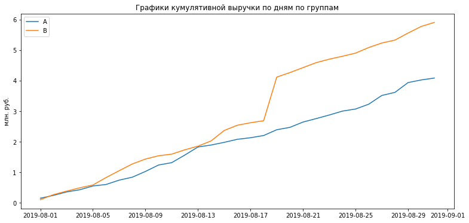

```python
plt.figure(figsize=(13,6));
plt.plot(cumulativeRevenueA['date'], cumulativeRevenueA['revenue']/1000000, label='A')
plt.plot(cumulativeRevenueB['date'], cumulativeRevenueB['revenue']/1000000, label='B')
plt.ylabel('млн. руб.')
plt.legend();
plt.title('Графики кумулятивной выручки по дням по группам');
```

**Сегменты А и В были практически одинаковыми в начале проведения теста. Через несколько дней сегмент В стал лучше группы А по показателю кумулятивной выручки, а к середине теста его преимущество резко усилилось. Возможно, причиной стали аномальные значения (крупные покупки) - проверим это позже.**

### График кумулятивного среднего чека по группам.

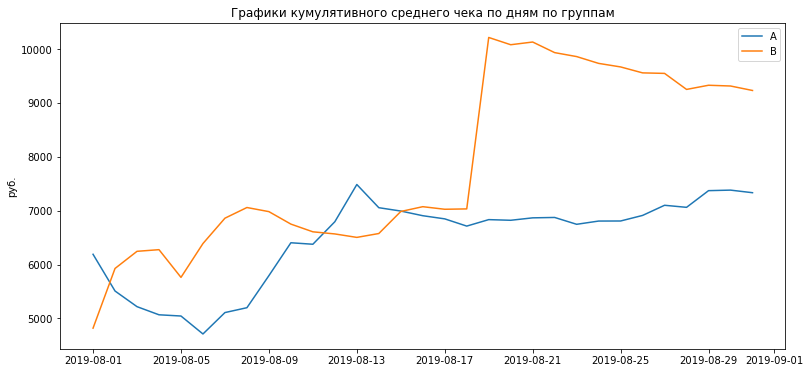

```python
# Посмотрим на динамику изменения кумулятивного среднего чека по группам
plt.figure(figsize=(13,6));
plt.plot(cumulativeRevenueA['date'], cumulativeRevenueA['revenue']/cumulativeRevenueA['orders'], label='A')
plt.plot(cumulativeRevenueB['date'], cumulativeRevenueB['revenue']/cumulativeRevenueB['orders'], label='B')
plt.ylabel('руб.')
plt.legend();
plt.title('Графики кумулятивного среднего чека по дням по группам');
```

**Сразу обращает на себя внимание резкий скачок кумулятивного чека Группы В в середине теста - вероятно, что в этот период в Группе В было сделано один / несколько очень крупных заказов. Это мы позже проверим на данных.**

**По Группе А кумулятивное значение среднего чека постоянно растет и к концу теста стабилизируется. Сегмент А кажется хуже сегмента В, однако выводы делать рано, данные стоит проанализировать на предмет наличия аномалий.**

```python
# Чтобы выявить аномалии, посмотрим на значения суммы заказов по дням в разрезе разных групп
ordersGrouped = orders.groupby(['date', 'group'])\
               .agg({'orderId' : 'nunique', 'userId' : 'nunique', 'revenue' : 'sum'}).reset_index()
ordersGrouped
```

|  | date | group | orderId | userId | revenue |
| --- | --- | --- | --- | --- | --- |
| 0 | 2019-08-01 | A | 24 | 20 | 148579 |
| 1 | 2019-08-01 | B | 21 | 20 | 101217 |
| 2 | 2019-08-02 | A | 20 | 19 | 93822 |
| 3 | 2019-08-02 | B | 24 | 23 | 165531 |
| 4 | 2019-08-03 | A | 24 | 24 | 112473 |
| ... | ... | ... | ... | ... | ... |
| 57 | 2019-08-29 | B | 20 | 20 | 231130 |
| 58 | 2019-08-30 | A | 11 | 10 | 86460 |
| 59 | 2019-08-30 | B | 24 | 24 | 215233 |
| 60 | 2019-08-31 | A | 12 | 12 | 61833 |
| 61 | 2019-08-31 | B | 20 | 20 | 133129 |

62 rows × 5 columns

```python
ordersA = ordersGrouped [ordersGrouped ['group']=='A']
ordersB = ordersGrouped [ordersGrouped ['group']=='B']
display(ordersA.head())
ordersB.head()
```

|  | date | group | orderId | userId | revenue |
| --- | --- | --- | --- | --- | --- |
| 0 | 2019-08-01 | A | 24 | 20 | 148579 |
| 2 | 2019-08-02 | A | 20 | 19 | 93822 |
| 4 | 2019-08-03 | A | 24 | 24 | 112473 |
| 6 | 2019-08-04 | A | 16 | 15 | 70825 |
| 8 | 2019-08-05 | A | 25 | 25 | 124218 |

|  | date | group | orderId | userId | revenue |
| --- | --- | --- | --- | --- | --- |
| 1 | 2019-08-01 | B | 21 | 20 | 101217 |
| 3 | 2019-08-02 | B | 24 | 23 | 165531 |
| 5 | 2019-08-03 | B | 16 | 16 | 114248 |
| 7 | 2019-08-04 | B | 17 | 16 | 108571 |
| 9 | 2019-08-05 | B | 23 | 23 | 92428 |

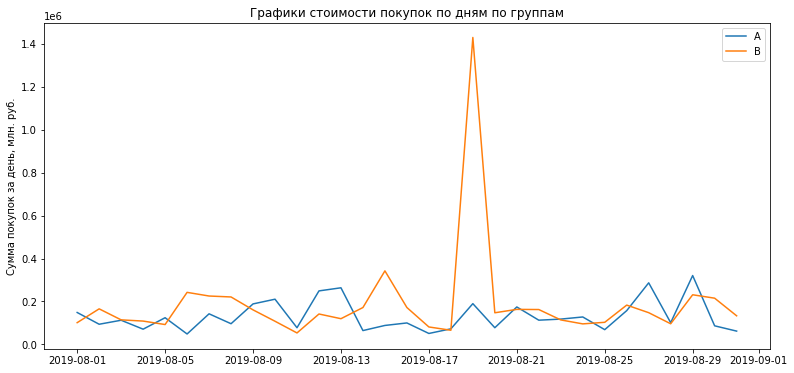

```python
plt.figure(figsize=(13,6));
plt.plot(ordersA['date'], ordersA['revenue'], label='A')
plt.plot(ordersA['date'], ordersB['revenue'], label='B')
plt.legend();
plt.title('Графики стоимости покупок по дням по группам');
plt.ylabel('Сумма покупок за день, млн. руб.');
```

**Аномалии в Группе В - 19.08.2019**

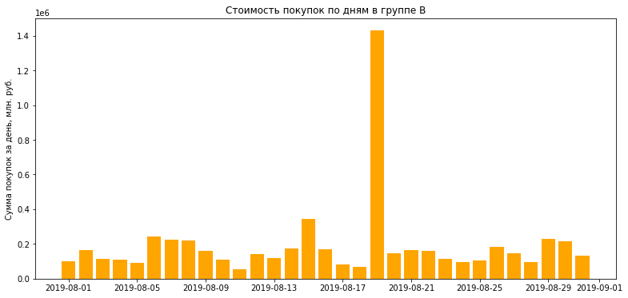

```python
#Отдельно по Группе В
plt.figure(figsize=(13,6));
plt.bar(ordersA['date'], ordersB['revenue'], label='B', color = 'orange');
plt.title('Стоимость покупок по дням в группе B');
plt.ylabel('Сумма покупок за день, млн. руб.');
```

### График относительного изменения кумулятивного среднего чека группы B к группе A.

```python
mergedCumulativeRevenue = cumulativeRevenueA\
.merge(cumulativeRevenueB, left_on='date', right_on='date', how='left', suffixes=['A', 'B'])
mergedCumulativeRevenue.head()
```

|  | date | revenueA | ordersA | revenueB | ordersB |
| --- | --- | --- | --- | --- | --- |
| 0 | 2019-08-01 | 148579 | 24 | 101217 | 21 |
| 1 | 2019-08-02 | 242401 | 44 | 266748 | 45 |
| 2 | 2019-08-03 | 354874 | 68 | 380996 | 61 |
| 3 | 2019-08-04 | 425699 | 84 | 489567 | 78 |
| 4 | 2019-08-05 | 549917 | 109 | 581995 | 101 |

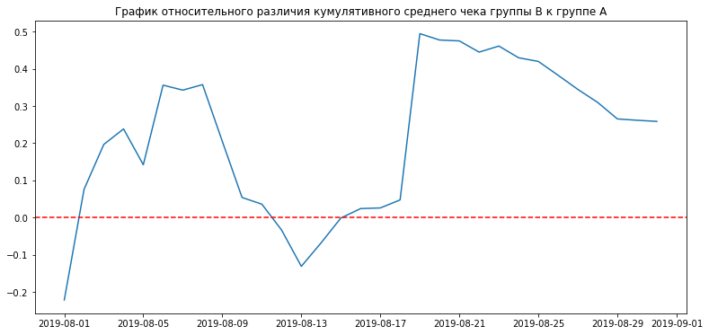

```python
plt.figure(figsize=(13,6));
plt.plot(mergedCumulativeRevenue['date'], (mergedCumulativeRevenue['revenueB']/mergedCumulativeRevenue['ordersB'])\
/(mergedCumulativeRevenue['revenueA']/mergedCumulativeRevenue['ordersA'])-1)
plt.title('График относительного различия кумулятивного среднего чека группы B к группе A');
plt.axhline(y=0, color='red', linestyle='--');
```

**Кривая отношения кумулятивного среднего чека группы B к группе A ведет себя нестабильно относительно 0, что также указывает на наличие в данных аномальных значений, которые резко меняли характер ее динамики.**

### График кумулятивной конверсии по группам.

```python
cumulativeData['conversion'] = cumulativeData['orders']/ cumulativeData['visitors']
cumulativeData
```

|  | date | group | orders | buyers | revenue | visitors | conversion |
| --- | --- | --- | --- | --- | --- | --- | --- |
| 0 | 2019-08-01 | A | 24 | 20 | 148579 | 719 | 0.033380 |
| 1 | 2019-08-01 | B | 21 | 20 | 101217 | 713 | 0.029453 |
| 2 | 2019-08-02 | A | 44 | 38 | 242401 | 1338 | 0.032885 |
| 3 | 2019-08-02 | B | 45 | 43 | 266748 | 1294 | 0.034776 |
| 4 | 2019-08-03 | A | 68 | 62 | 354874 | 1845 | 0.036856 |
| ... | ... | ... | ... | ... | ... | ... | ... |
| 57 | 2019-08-29 | B | 596 | 544 | 5559398 | 17708 | 0.033657 |
| 58 | 2019-08-30 | A | 545 | 493 | 4022970 | 18037 | 0.030216 |
| 59 | 2019-08-30 | B | 620 | 567 | 5774631 | 18198 | 0.034070 |
| 60 | 2019-08-31 | A | 557 | 503 | 4084803 | 18736 | 0.029729 |
| 61 | 2019-08-31 | B | 640 | 586 | 5907760 | 18916 | 0.033834 |

62 rows × 7 columns

```python
cumulativeDataA = cumulativeData[cumulativeData['group']=='A']
cumulativeDataB = cumulativeData[cumulativeData['group']=='B']
display(cumulativeDataA.head(5))
cumulativeDataB.head(5)
```

|  | date | group | orders | buyers | revenue | visitors | conversion |
| --- | --- | --- | --- | --- | --- | --- | --- |
| 0 | 2019-08-01 | A | 24 | 20 | 148579 | 719 | 0.033380 |
| 2 | 2019-08-02 | A | 44 | 38 | 242401 | 1338 | 0.032885 |
| 4 | 2019-08-03 | A | 68 | 62 | 354874 | 1845 | 0.036856 |
| 6 | 2019-08-04 | A | 84 | 77 | 425699 | 2562 | 0.032787 |
| 8 | 2019-08-05 | A | 109 | 100 | 549917 | 3318 | 0.032851 |

|  | date | group | orders | buyers | revenue | visitors | conversion |
| --- | --- | --- | --- | --- | --- | --- | --- |
| 1 | 2019-08-01 | B | 21 | 20 | 101217 | 713 | 0.029453 |
| 3 | 2019-08-02 | B | 45 | 43 | 266748 | 1294 | 0.034776 |
| 5 | 2019-08-03 | B | 61 | 59 | 380996 | 1803 | 0.033833 |
| 7 | 2019-08-04 | B | 78 | 75 | 489567 | 2573 | 0.030315 |
| 9 | 2019-08-05 | B | 101 | 98 | 581995 | 3280 | 0.030793 |

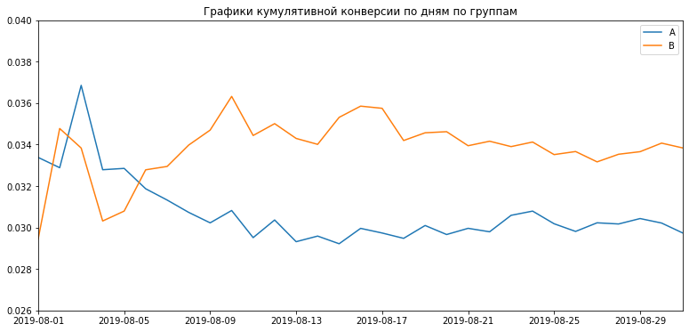

```python
plt.figure(figsize=(13,6));
plt.plot(cumulativeDataA['date'], cumulativeDataA['conversion'], label='A')
plt.plot(cumulativeDataB['date'], cumulativeDataB['conversion'], label='B')
plt.legend();
plt.axis([dt.datetime(2019, 8, 1), dt.datetime(2019, 8, 31), 0.026, 0.04]);
plt.title('Графики кумулятивной конверсии по дням по группам');
```

### График относительного изменения кумулятивной конверсии группы B к группе A.

```python
mergedCumulativeConversions = cumulativeDataA[['date','conversion']]\
.merge(cumulativeDataB[['date','conversion']], left_on='date', right_on='date', how='left', suffixes=['A', 'B'])
mergedCumulativeConversions.head()
```

|  | date | conversionA | conversionB |
| --- | --- | --- | --- |
| 0 | 2019-08-01 | 0.033380 | 0.029453 |
| 1 | 2019-08-02 | 0.032885 | 0.034776 |
| 2 | 2019-08-03 | 0.036856 | 0.033833 |
| 3 | 2019-08-04 | 0.032787 | 0.030315 |
| 4 | 2019-08-05 | 0.032851 | 0.030793 |

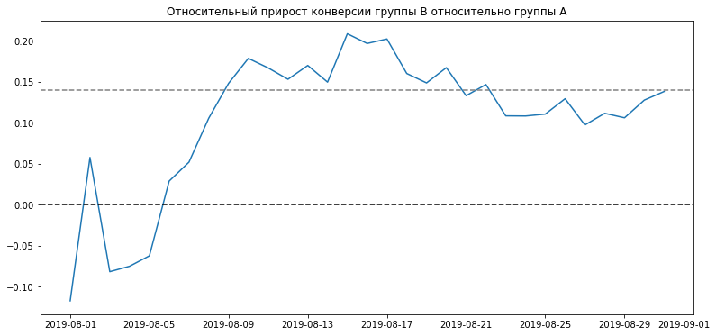

```python
plt.figure(figsize=(13,6));
plt.plot(mergedCumulativeConversions['date'], \
         mergedCumulativeConversions['conversionB']/mergedCumulativeConversions['conversionA']-1);
plt.title("Относительный прирост конверсии группы B относительно группы A");
plt.axhline(y=0, color='black', linestyle='--');
plt.axhline(y=0.14, color='grey', linestyle='--');
```

### Точечный график (scatterplot) количества заказов по пользователям.

```python
# Считаем количество заказов пользователей
ordersByUsers = (
    orders.groupby('userId', as_index=False)
    .agg({'orderId': 'nunique'})
)

ordersByUsers.columns = ['userId', 'orders']

print(ordersByUsers.sort_values(by='orders', ascending=False).head(10))
```

```
          userId  orders
1023  4256040402      11
591   2458001652      11
569   2378935119       9
487   2038680547       8
44     199603092       5
744   3062433592       5
55     237748145       5
917   3803269165       5
299   1230306981       5
897   3717692402       5
```

**Есть активные пользователи, которые за месяц совершили до 11 заказов.**

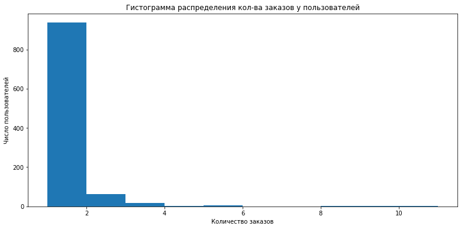

```python
plt.figure(figsize=(13,6));
plt.hist(ordersByUsers['orders']);
plt.xlabel('Количество заказов');
plt.ylabel('Число пользователей');
plt.title('Гистограмма распределения кол-ва заказов у пользователей');
```

**Большинство пользователей сделали всего 1 заказ, есть достаточное количество пользователей с 2 заказами - вместе их 97% от всех посетителей**

```python
#Около 97% пользователей делали 1-2 заказа
round(ordersByUsers[ordersByUsers['orders']<=2].count() / len(ordersByUsers) *100, 1)
```

```
userId    97.1
orders    97.1
dtype: float64
```

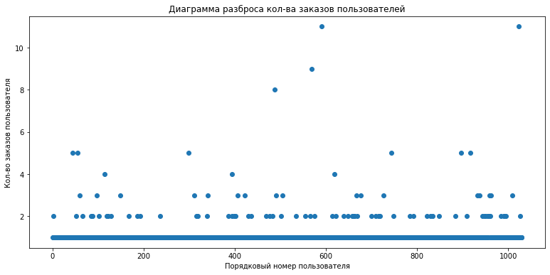

```python
plt.figure(figsize=(13,6));
x_values = pd.Series(range(0,len(ordersByUsers)))
plt.scatter(x_values, ordersByUsers['orders']);
plt.xlabel('Порядковый номер пользователя');
plt.ylabel('Кол-во заказов пользователя');
plt.title('Диаграмма разброса кол-ва заказов пользователей');
```

**Достаточно много пользователей с 2-3 заказами. Посчитаем выборочные перцентили количества заказов на одного пользователя.**

### 95-й и 99-й перцентили количества заказов на пользователя: выбор границы для определения аномальных пользователей.

```python
print(np.percentile(ordersByUsers['orders'], [95, 97.5, 99]))
```

```
[2. 3. 4.]
```

**Менее 5% пользователей оформляли больше 2 заказов, менее 1% пользователей сделали более 4 заказов. Дополнительно посчитаем 97,5-ый персентиль.**

### Точечный график (scatterplot) стоимостей заказов.

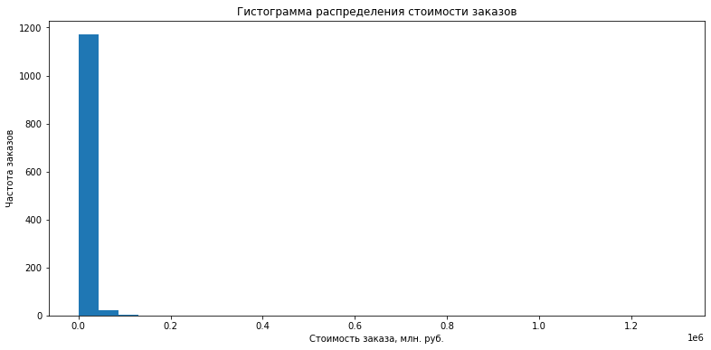

```python
plt.figure(figsize=(13,6));
plt.hist(orders['revenue'], bins = 30);
plt.xlabel('Стоимость заказа, млн. руб.');
plt.ylabel('Частота заказов');
plt.title('Гистограмма распределения стоимости заказов');
```

**С учетом автоматически выбранной по данным шкалы по оси х есть заказы стоимостью в районе 1,2 млн. руб., но абсолютное большинство заказов гораздо меньше по стоимости.**

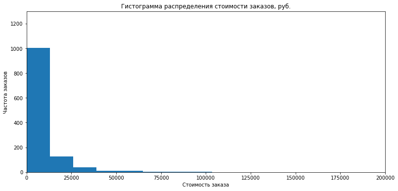

```python
# Обрежем хвост по оси Х
plt.figure(figsize=(13,6));
plt.hist(orders['revenue'], bins = 100);
plt.xlabel('Стоимость заказа');
plt.ylabel('Частота заказов');
plt.title('Гистограмма распределения стоимости заказов, руб.');
plt.axis([0, 200000, 0, 1300]);
```

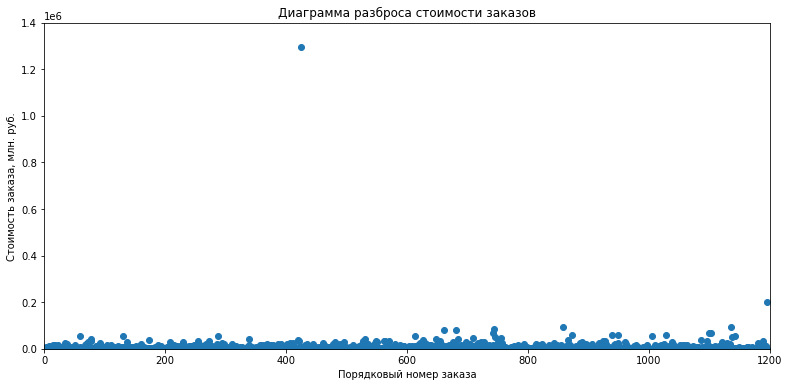

```python
plt.figure(figsize=(13,6));
x_values = pd.Series(range(0,len(orders['revenue'])))
plt.scatter(x_values, orders['revenue']);
plt.xlabel('Порядковый номер заказа');
plt.ylabel('Стоимость заказа, млн. руб.');
plt.title('Диаграмма разброса стоимости заказов');
plt.axis([0, 1200, 0, 1400000]);
```

**Без ограничений по стоимости заказов, на диаграмме разброса виден заказ стоимостью около 1,3 млн. руб. Также значительно ниже еще один выброс - заказ стоимостью около 200 тыс. руб. Применим zoom и посмотрим на данные поближе, изменив шкалу Оу - основной объем заказов меньше 100 тыс. руб.**

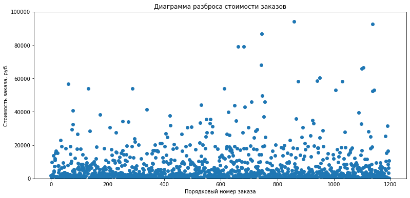

```python
plt.figure(figsize=(13,6));
x_values = pd.Series(range(0,len(orders['revenue'])));
plt.scatter(x_values, orders['revenue']);
plt.ylim(0, 100000);
plt.xlabel('Порядковый номер заказа');
plt.ylabel('Стоимость заказа, руб.');
plt.title('Диаграмма разброса стоимости заказов');
```

**Есть крупные заказы, но заказов стоимостью более 40 тыс. руб. не много, основная часть заказов - меньше 20 тыс. руб.**

### 95-й и 99-й перцентили стоимости заказов (средних чеков): выбор границы для определения аномальных заказов.

```python
print(np.percentile(orders['revenue'], [95, 97.5, 99]))
```

```
[28000.  39530.  58233.2]
```

- Менее 5% пользователей оформили заказ стоимостью более 28 тыс. руб.
- менее 1% пользователей сделали заказ стоимостью свыше 58234 руб.
- менее 2,5% посетителей сделали заказ стоимостью свыше 39530 руб.

**Выберем 40 тыс. руб. (97,5-персентиль) за верхнюю границу стоимости заказа, тем самым мы отбросим около 2,5% заказов с аномально высокой стоимостью чека.**

### Расчет статистической значимости различий среднего количества заказов (конверсии) между группами («сырые» данные).

```python
# Расчитаем по дням в разрезе групп кол-во посетителей, кол-во заказов и сумму заказов, в т.ч. кумулятивно
visitorsADaily = visitors[visitors['group'] == 'A'][['date', 'visitors']]
visitorsADaily.columns = ['date', 'visitorsPerDateA']

visitorsACummulative = visitorsADaily.apply(
    lambda x: visitorsADaily[visitorsADaily['date'] <= x['date']].agg(
        {'date': 'max', 'visitorsPerDateA': 'sum'}
    ),
    axis=1,
)
visitorsACummulative.columns = ['date', 'visitorsCummulativeA']

visitorsBDaily = visitors[visitors['group'] == 'B'][['date', 'visitors']]
visitorsBDaily.columns = ['date', 'visitorsPerDateB']

visitorsBCummulative = visitorsBDaily.apply(
    lambda x: visitorsBDaily[visitorsBDaily['date'] <= x['date']].agg(
        {'date': 'max', 'visitorsPerDateB': 'sum'}
    ),
    axis=1,
)
visitorsBCummulative.columns = ['date', 'visitorsCummulativeB']

display(visitorsADaily.head())
display(visitorsBDaily.head())
display(visitorsACummulative.head())
visitorsBCummulative.head()
```

|  | date | visitorsPerDateA |
| --- | --- | --- |
| 0 | 2019-08-01 | 719 |
| 1 | 2019-08-02 | 619 |
| 2 | 2019-08-03 | 507 |
| 3 | 2019-08-04 | 717 |
| 4 | 2019-08-05 | 756 |

|  | date | visitorsPerDateB |
| --- | --- | --- |
| 31 | 2019-08-01 | 713 |
| 32 | 2019-08-02 | 581 |
| 33 | 2019-08-03 | 509 |
| 34 | 2019-08-04 | 770 |
| 35 | 2019-08-05 | 707 |

|  | date | visitorsCummulativeA |
| --- | --- | --- |
| 0 | 2019-08-01 | 719 |
| 1 | 2019-08-02 | 1338 |
| 2 | 2019-08-03 | 1845 |
| 3 | 2019-08-04 | 2562 |
| 4 | 2019-08-05 | 3318 |

|  | date | visitorsCummulativeB |
| --- | --- | --- |
| 31 | 2019-08-01 | 713 |
| 32 | 2019-08-02 | 1294 |
| 33 | 2019-08-03 | 1803 |
| 34 | 2019-08-04 | 2573 |
| 35 | 2019-08-05 | 3280 |

```python
ordersADaily = (
    orders[orders['group'] == 'A'][['date', 'orderId', 'userId', 'revenue']]
    .groupby('date', as_index=False)
    .agg({'orderId': pd.Series.nunique, 'revenue': 'sum'})
)
ordersADaily.columns = ['date', 'ordersPerDateA', 'revenuePerDateA']

ordersACummulative = ordersADaily.apply(
    lambda x: ordersADaily[ordersADaily['date'] <= x['date']].agg(
        {'date': 'max', 'ordersPerDateA': 'sum', 'revenuePerDateA': 'sum'}
    ),
    axis=1,
).sort_values(by=['date'])
ordersACummulative.columns = [
    'date',
    'ordersCummulativeA',
    'revenueCummulativeA',
]

ordersBDaily = (
    orders[orders['group'] == 'B'][['date', 'orderId', 'userId', 'revenue']]
    .groupby('date', as_index=False)
    .agg({'orderId': pd.Series.nunique, 'revenue': 'sum'})
)
ordersBDaily.columns = ['date', 'ordersPerDateB', 'revenuePerDateB']

ordersBCummulative = ordersBDaily.apply(
    lambda x: ordersBDaily[ordersBDaily['date'] <= x['date']].agg(
        {'date': 'max', 'ordersPerDateB': 'sum', 'revenuePerDateB': 'sum'}
    ),
    axis=1,
).sort_values(by=['date'])
ordersBCummulative.columns = [
    'date',
    'ordersCummulativeB',
    'revenueCummulativeB',
]
display(ordersADaily.head())
display(ordersBDaily.head())
display(ordersACummulative.head())
ordersBCummulative.head()
```

|  | date | ordersPerDateA | revenuePerDateA |
| --- | --- | --- | --- |
| 0 | 2019-08-01 | 24 | 148579 |
| 1 | 2019-08-02 | 20 | 93822 |
| 2 | 2019-08-03 | 24 | 112473 |
| 3 | 2019-08-04 | 16 | 70825 |
| 4 | 2019-08-05 | 25 | 124218 |

|  | date | ordersPerDateB | revenuePerDateB |
| --- | --- | --- | --- |
| 0 | 2019-08-01 | 21 | 101217 |
| 1 | 2019-08-02 | 24 | 165531 |
| 2 | 2019-08-03 | 16 | 114248 |
| 3 | 2019-08-04 | 17 | 108571 |
| 4 | 2019-08-05 | 23 | 92428 |

|  | date | ordersCummulativeA | revenueCummulativeA |
| --- | --- | --- | --- |
| 0 | 2019-08-01 | 24 | 148579 |
| 1 | 2019-08-02 | 44 | 242401 |
| 2 | 2019-08-03 | 68 | 354874 |
| 3 | 2019-08-04 | 84 | 425699 |
| 4 | 2019-08-05 | 109 | 549917 |

|  | date | ordersCummulativeB | revenueCummulativeB |
| --- | --- | --- | --- |
| 0 | 2019-08-01 | 21 | 101217 |
| 1 | 2019-08-02 | 45 | 266748 |
| 2 | 2019-08-03 | 61 | 380996 |
| 3 | 2019-08-04 | 78 | 489567 |
| 4 | 2019-08-05 | 101 | 581995 |

```python
data_all = (
    ordersADaily.merge(
        ordersBDaily, left_on='date', right_on='date', how='left'
    )
    .merge(ordersACummulative, left_on='date', right_on='date', how='left')
    .merge(ordersBCummulative, left_on='date', right_on='date', how='left')
    .merge(visitorsADaily, left_on='date', right_on='date', how='left')
    .merge(visitorsBDaily, left_on='date', right_on='date', how='left')
    .merge(visitorsACummulative, left_on='date', right_on='date', how='left')
    .merge(visitorsBCummulative, left_on='date', right_on='date', how='left')
)

data_all.head(5)
```

|  | date | ordersPerDateA | revenuePerDateA | ordersPerDateB | revenuePerDateB | ordersCummulativeA | revenueCummulativeA | ordersCummulativeB | revenueCummulativeB | visitorsPerDateA | visitorsPerDateB | visitorsCummulativeA | visitorsCummulativeB |
| --- | --- | --- | --- | --- | --- | --- | --- | --- | --- | --- | --- | --- | --- |
| 0 | 2019-08-01 | 24 | 148579 | 21 | 101217 | 24 | 148579 | 21 | 101217 | 719 | 713 | 719 | 713 |
| 1 | 2019-08-02 | 20 | 93822 | 24 | 165531 | 44 | 242401 | 45 | 266748 | 619 | 581 | 1338 | 1294 |
| 2 | 2019-08-03 | 24 | 112473 | 16 | 114248 | 68 | 354874 | 61 | 380996 | 507 | 509 | 1845 | 1803 |
| 3 | 2019-08-04 | 16 | 70825 | 17 | 108571 | 84 | 425699 | 78 | 489567 | 717 | 770 | 2562 | 2573 |
| 4 | 2019-08-05 | 25 | 124218 | 23 | 92428 | 109 | 549917 | 101 | 581995 | 756 | 707 | 3318 | 3280 |

```python
#Для пользователей, совершивших хотя бы 1 заказ, считаем число заказов (в разрезе групп).
ordersByUsersA = (
    orders[orders['group'] == 'A']
    .groupby('userId', as_index=False)
    .agg({'orderId': 'nunique'})
)
ordersByUsersA.columns = ['userId', 'orders']

ordersByUsersB = (
    orders[orders['group'] == 'B']
    .groupby('userId', as_index=False)
    .agg({'orderId': 'nunique'})
)
ordersByUsersB.columns = ['userId', 'orders']

display(ordersByUsersA.head())
ordersByUsersB.head()
```

|  | userId | orders |
| --- | --- | --- |
| 0 | 8300375 | 1 |
| 1 | 11685486 | 1 |
| 2 | 54447517 | 1 |
| 3 | 66685450 | 1 |
| 4 | 78758296 | 1 |

|  | userId | orders |
| --- | --- | --- |
| 0 | 5114589 | 1 |
| 1 | 6958315 | 1 |
| 2 | 8300375 | 1 |
| 3 | 39475350 | 1 |
| 4 | 47206413 | 1 |

```python
# Пользователям, которые ничего не заказали, присвоим нули.
# Их количество равно разнице между суммой посетителей и количеством записей о заказах
sampleA = pd.concat([ordersByUsersA['orders'],\
                     pd.Series(0, index=np.arange(data_all['visitorsPerDateA'].sum() - len(ordersByUsersA['orders'])), \
                               name='orders')],axis=0)

sampleB = pd.concat([ordersByUsersB['orders'],\
                     pd.Series(0, index=np.arange(data_all['visitorsPerDateB'].sum() - len(ordersByUsersB['orders'])), \
                               name='orders')],axis=0)
```

**Чтобы посчитать статистическую значимость различий в среднем количестве заказов (конверсии) между группами по результатам месяца теста, применим тест Манна-Уитни.**

**Сформулируем гипотезы.**

- Н0: различий в конверсии между группами нет.
- Н1: различия в конверсии между группами есть.

```python
print('p-value =', "{0:.5f}".format(stats.mannwhitneyu(sampleA, sampleB)[1], alternative="two-sided"))
print('относительные различия в конверсии =', "{0:.3f}".format(sampleB.mean() / sampleA.mean() - 1))
```

```
p-value = 0.01679
относительные различия в конверсии = 0.138
```

**P-value<0.05, а значит нулевую гипотезу об отсутствии различий в среднем количестве заказов (конверсии) между группами мы отвергаем. То есть по "сырым" данным можно утверждать, что между группами есть статистически значимые различия в среднем количестве заказов.**

**Конверсия Группы В лучше относительно конверсии Группы А на 13,8%.**

### Расчет статистической значимости различий в среднем чеке заказа между группами («сырые» данные).

**Чтобы посчитать статистическую значимость различий в среднем чеке между группами по результатам месяца теста, передадим критерию mannwhitneyu() данные о выручке с заказов.**

**Сформулируем гипотезы:**

- Н0: различий в среднем чеке между группами нет.
- Н1: различия в среднем чеке между группами есть.

```python
print('p-value =', '{0:.3f}'\
      .format(stats.mannwhitneyu(orders[orders['group']=='A']['revenue'], orders[orders['group']=='B']['revenue'])[1]\
             , alternative="two-sided"))
print('относительные различия в среднем чеке =', '{0:.3f}'\
      .format(orders[orders['group']=='B']['revenue'].mean()/orders[orders['group']=='A']['revenue'].mean()-1))
```

```
p-value = 0.729
относительные различия в среднем чеке = 0.259
```

**P-value>0.05, а значит нулевую гипотезу об отсутствии различий в среднем чеке заказов между группами мы отвергнуть не можем. То есть по "сырым данным" можно утверждать, что между группами нет статистически значимых различий в среднем чеке заказов.** **При этом относительное различие среднего чека между Группами А и В составляют почти 26%. Такое высокое значение относительной разницы между средним чеком по сегментам и при этом отсутствие статистической значимости - жирный намек на наличие аномалий.**

### Расчет статистической значимости различий среднего количества заказов (конверсии) между группами («очищенные» данные).

**Очистим данные от аномалий. Выше были рассчитаны 95-й, 97,5-й и 99-й перцентили числа заказов на одного пользователя - 2, 3 и 4 заказа соответственно. С учетом продолжительности теста в 1 месяц, выберем 3 заказа на одного пользователя за верхнюю границу числа заказов, остальных пользователей будем считать аномальными. Так мы уберём 2,5% пользователей с наибольшим числом заказов.**

```python
#срез пользователей с числом заказов больше 3
usersWithManyOrders = pd.concat(
    [
        ordersByUsersA[ordersByUsersA['orders'] > 3]['userId'],
        ordersByUsersB[ordersByUsersB['orders'] >3]['userId'],
    ],
    axis=0,
)
# таких получилось 12 (если отбросить пользователей с 3 заказами, то число аномальных пользователей вырастит до 24)
usersWithManyOrders.count()
```

```
12
```

**95-й, 97,5-й и 99-й перцентили средних чеков равны 28000, 39530 и 58234 рублям соответствено. Выберем 40000 руб. (97,5-персентиль) за верхнюю границу стоимости заказа, тем самым мы отбросим около 2,5% заказов с аномально высокой стоимостью чека. Так мы уберем около 2,5% заказов с наибольшей стоимостью.**

```python
# срез пользователей, совершивших заказы дороже 40 000
usersWithExpensiveOrders = orders[orders['revenue'] > 40000]['userId']

# таких пользователей получилось 29
usersWithExpensiveOrders.count()
```

```
29
```

```python
# объединим аномальных пользователей, отобранных по 2 критериям, в единой таблице, удалив дубликаты
abnormalUsers = (
    pd.concat([usersWithManyOrders, usersWithExpensiveOrders], axis=0)
    .drop_duplicates()
    .sort_values()
)
abnormalUsers.head(5)
```

```
1099    148427295
18      199603092
23      237748145
684     358944393
648     382846391
Name: userId, dtype: int64
```

```python
#Всего удалим данные 34 "аномальных" пользователей
abnormalUsers.count()
```

```
34
```

```python
#Очистим выборки количества заказов пользователей по группам теста от заказов "аномальных" пользователей:
sampleAFiltered = pd.concat(
    [
        ordersByUsersA[np.logical_not(ordersByUsersA['userId'].isin(abnormalUsers))]['orders'],
        pd.Series(0, index=np.arange(data_all['visitorsPerDateA'].sum() - len(ordersByUsersA['orders'])), name='orders'),
    ],
    axis=0,
)

sampleBFiltered = pd.concat(
    [
        ordersByUsersB[np.logical_not(ordersByUsersB['userId'].isin(abnormalUsers))]['orders'],
        pd.Series(0, index=np.arange(data_all['visitorsPerDateB'].sum() - len(ordersByUsersB['orders'])), name='orders'),
    ],
    axis=0,
)
```

**Чтобы посчитать статистическую значимость различий в среднем количестве заказов (конверсии) между группами по результатам теста по очищенным данным, снова сформулируем гипотезы.**

```python
print('p-value =', '{0:.5f}'.format(stats.mannwhitneyu(sampleAFiltered, sampleBFiltered)[1]\
                                   , alternative="two-sided"))
print('относительные различия в конверсии =', '{0:.3f}'.format(sampleBFiltered.mean()/sampleAFiltered.mean()-1))
```

```
p-value = 0.00931
относительные различия в конверсии = 0.164
```

**P-value еще больше снизилась, вывод не изменился: теперь с еще большей уверенностью мы отвергаем нулевую гипотезу об отсутствии различий в среднем количестве заказов (конверсии) между группами. По "очищенным данным" можно с еще большей уверенностью утверждать, что между группами есть статистически значимые различия в среднем количестве заказов.**

**Конверсия в заказы Группы В на "очищенных данных" выросла относительно конверсии Группы А до 16,4% (с 13,8% по сырым данным).**

### Расчет статистической значимости различий в среднем чеке заказа между группами по «очищенным» данным.

```python
#Очистим выборки количества заказов пользователей по группам теста от заказов "аномальных" пользователей:
sampleCFiltered = orders[np.logical_and(orders['group'] == 'A', \
                                        np.logical_not(orders['userId'].isin(abnormalUsers)))]['revenue']

sampleDFiltered = orders[np.logical_and(orders['group'] == 'B',\
                                        np.logical_not(orders['userId'].isin(abnormalUsers)))]['revenue']
```

**Чтобы посчитать статистическую значимость различий в среднем чеке между группами по результатам теста теперь по очищенным данным, снова сформулируем гипотезы:**

```python
print('p-value =','{0:.5f}'.format(stats.mannwhitneyu(sampleCFiltered, sampleDFiltered)[1]\
                                  , alternative="two-sided"))
print('относительные различия в среднем чеке =', '{0:.3f}'.format(sampleCFiltered.mean()/sampleDFiltered.mean()-1))
```

```
p-value = 0.71098
относительные различия в среднем чеке = -0.057
```

### Результаты теста.

**Перед тем как сделать итоговые выводы, сравним графики относительного изменения кумулятивного среднего чека и относительной кумулятивной конверсии по сырым и очищенным данным. Для этого уберем аномальных пользователей из датасета orders**

```python
orders.head()
```

|  | orderId | userId | date | revenue | group |
| --- | --- | --- | --- | --- | --- |
| 0 | 3667963787 | 3312258926 | 2019-08-15 | 1650 | B |
| 1 | 2804400009 | 3642806036 | 2019-08-15 | 730 | B |
| 2 | 2961555356 | 4069496402 | 2019-08-15 | 400 | A |
| 3 | 3797467345 | 1196621759 | 2019-08-15 | 9759 | B |
| 4 | 2282983706 | 2322279887 | 2019-08-15 | 2308 | B |

```python
abnormalUsers.head()
```

```
1099    148427295
18      199603092
23      237748145
684     358944393
648     382846391
Name: userId, dtype: int64
```

```python
# все заказы не аномальных пользователей
ordersClean =orders[~orders['userId'].isin(abnormalUsers)]
```

```python
# все заказы не аномальных пользователей отдельно по группам
ordersCleanA =orders[~orders['userId'].isin(abnormalUsers)].query('group=="A"')
ordersCleanB =orders[~orders['userId'].isin(abnormalUsers)].query('group=="B"')
```

```python
# проверка на отсутсвие в ощищенных данных первого аномального пользователя из abnormalUsers с userId = 148427295
ordersCleanA[ordersCleanA['userId']==148427295]
ordersCleanB[ordersCleanB['userId']==148427295]
```

|  | orderId | userId | date | revenue | group |
| --- | --- | --- | --- | --- | --- |

```python
ordersAggregatedClean = datesGroups\
.apply(lambda x: ordersClean[np.logical_and(ordersClean['date'] <= x['date'], ordersClean['group'] == x['group'])]\
.agg({'date' : 'max', 'group' : 'max', 'orderId' : 'nunique', 'userId' : 'nunique', 'revenue' : 'sum'}), axis=1)\
.sort_values(by=['date','group'])
```

```python
cumulativeDataClean = ordersAggregatedClean\
                        .merge(visitorsAggregated, left_on=['date', 'group'], right_on=['date', 'group'])
cumulativeDataClean.columns = ['date', 'group', 'orders', 'buyers', 'revenue', 'visitors']
```

```python
cumulativeRevenueCleanA = cumulativeDataClean[cumulativeDataClean['group']=='A'][['date','revenue', 'orders']]
cumulativeRevenueCleanB = cumulativeDataClean[cumulativeDataClean['group']=='B'][['date','revenue', 'orders']]
```

```python
mergedCumulativeRevenueClean = cumulativeRevenueCleanA\
                                .merge(cumulativeRevenueCleanB, left_on='date', right_on='date', how='left', \
                                       suffixes=['A', 'B'])
mergedCumulativeRevenueClean.head()
```

|  | date | revenueA | ordersA | revenueB | ordersB |
| --- | --- | --- | --- | --- | --- |
| 0 | 2019-08-01 | 142779 | 23 | 78258 | 19 |
| 1 | 2019-08-02 | 236601 | 43 | 240301 | 42 |
| 2 | 2019-08-03 | 349074 | 67 | 354549 | 58 |
| 3 | 2019-08-04 | 415489 | 80 | 460320 | 74 |
| 4 | 2019-08-05 | 539707 | 105 | 550328 | 96 |

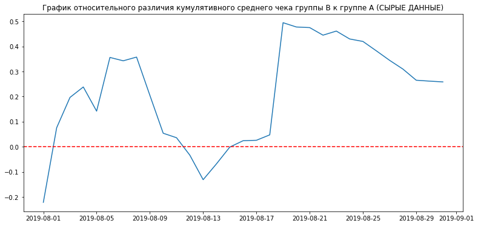

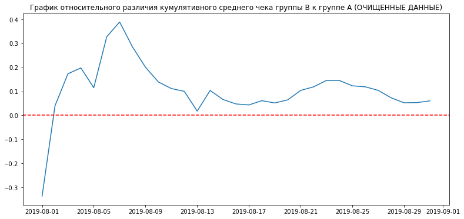

```python
plt.figure(figsize=(13,6));
plt.plot(mergedCumulativeRevenue['date'], \
         (mergedCumulativeRevenue['revenueB']/mergedCumulativeRevenue['ordersB'])\
        /(mergedCumulativeRevenue['revenueA']/mergedCumulativeRevenue['ordersA'])-1)
plt.title('График относительного различия кумулятивного среднего чека группы B к группе A (СЫРЫЕ ДАННЫЕ)');
plt.axhline(y=0, color='red', linestyle='--');
plt.show()

plt.figure(figsize=(13,6));
plt.plot(mergedCumulativeRevenueClean['date'], \
         (mergedCumulativeRevenueClean['revenueB']/mergedCumulativeRevenueClean['ordersB'])\
        /(mergedCumulativeRevenueClean['revenueA']/mergedCumulativeRevenueClean['ordersA'])-1);
plt.title('График относительного различия кумулятивного среднего чека группы B к группе A (ОЧИЩЕННЫЕ ДАННЫЕ)');
plt.axhline(y=0, color='red', linestyle='--');
```

```python
cumulativeDataClean['conversion'] = cumulativeDataClean['orders']/ cumulativeDataClean['visitors']
```

```python
cumulativeDataCleanA = cumulativeData[cumulativeData['group']=='A']
cumulativeDataCleanB = cumulativeData[cumulativeData['group']=='B']
```

```python
mergedCumulativeConversionsClean = cumulativeDataCleanA[['date','conversion']]\
                                    .merge(cumulativeDataCleanB[['date','conversion']], \
                                           left_on='date', right_on='date', how='left', suffixes=['A', 'B'])
mergedCumulativeConversionsClean.head()
```

|  | date | conversionA | conversionB |
| --- | --- | --- | --- |
| 0 | 2019-08-01 | 0.033380 | 0.029453 |
| 1 | 2019-08-02 | 0.032885 | 0.034776 |
| 2 | 2019-08-03 | 0.036856 | 0.033833 |
| 3 | 2019-08-04 | 0.032787 | 0.030315 |
| 4 | 2019-08-05 | 0.032851 | 0.030793 |

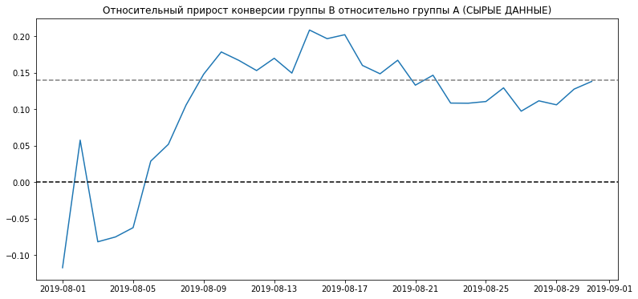

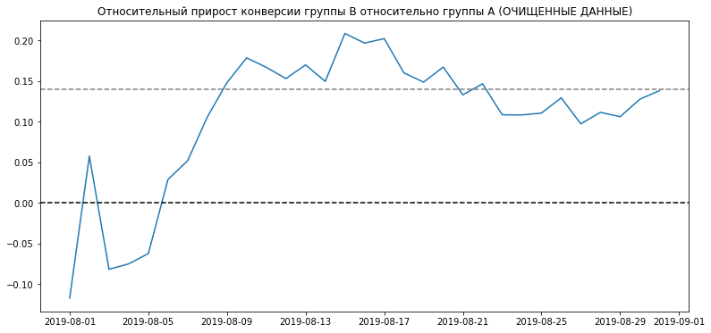

```python
plt.figure(figsize=(13,6));
plt.plot(mergedCumulativeConversions['date'], \
         mergedCumulativeConversions['conversionB']/mergedCumulativeConversions['conversionA']-1);
plt.title("Относительный прирост конверсии группы B относительно группы A (СЫРЫЕ ДАННЫЕ)");
plt.axhline(y=0, color='black', linestyle='--');
plt.axhline(y=0.14, color='grey', linestyle='--');
plt.show()

plt.figure(figsize=(13,6));
plt.plot(mergedCumulativeConversionsClean['date'], \
         mergedCumulativeConversionsClean['conversionB']/mergedCumulativeConversionsClean['conversionA']-1);
plt.title("Относительный прирост конверсии группы B относительно группы A (ОЧИЩЕННЫЕ ДАННЫЕ)");
plt.axhline(y=0, color='black', linestyle='--');
plt.axhline(y=0.14, color='grey', linestyle='--');
```

## Общие выводы

**Рекоммендации:**

- Предлагается продолжить тест с целью получения бОльшего объема данных, на основе которых можно будет дополнительно протестировать Группы на статистическую значимость различий их среднего чека.